# Understanding ‘Control’ in Statistical Analysis

Author

Heeyoung Lee

Published

May 18, 2025

## What Does It Mean to “Control” in Statistical Analysis?

In statistical analysis, “controlling” for a variable means accounting for its effect when examining the relationship between other variables. This helps us understand the true relationship between an independent variable (IV) and a dependent variable (DV) by removing the influence of potentially confounding factors.

Mathematically, we move from a simple bivariate model:

$$Y = \beta_0 + \beta_1 X + \varepsilon$$

To a multiple regression model that includes the control variable:

$$Y = \beta_0 + \beta_1 X + \beta_2 Z + \varepsilon$$

Where:

- $Y$ is the dependent variable
- $X$ is the independent variable of interest
- $Z$ is the control variable
- $\beta_0$ is the intercept
- $\beta_1$ is the coefficient for $X$ (our primary interest)
- $\beta_2$ is the coefficient for $Z$ (the control variable)
- $\varepsilon$ is the error term

**Key Points: Controlling Variables**

- Isolates the unique effect of the independent variable
- Removes confounding influences
- Answers: “What would be the relationship if control variable were held constant?”
- Essential in observational studies where randomization isn’t possible
- Increases the internal validity of findings

### 1. Conceptual Understanding

When we say we’re “controlling” for a variable, we’re asking:

“What would be the relationship between my independent and dependent variables if the control variable were held constant?”

This isolates the unique effect of our independent variable on the dependent variable.

The coefficient $\beta_1$ in the multiple regression represents the expected change in $Y$ for a one-unit change in $X$, **holding $Z$ constant**.

### 2. Data Generation

Let’s create simulated data to demonstrate this concept:

```r
# Set seed for reproducibility
set.seed(123)

# Generate simulated data
n <- 1000

# Scenario:
# IV = Study Hours (hours spent studying)
# Control = Prior Knowledge (measured on a scale of 1-10)
# DV = Test Score (0-100)

# Generate the control variable (Prior Knowledge)
prior_knowledge <- runif(n, 1, 10)

# Generate the independent variable (Study Hours) with some relationship to Prior Knowledge
study_hours <- 2 + 0.2 * prior_knowledge + rnorm(n, 0, 1)

# Generate the dependent variable (Test Score)
# It's influenced by both Prior Knowledge and Study Hours
test_score <- 30 + 3 * study_hours + 5 * prior_knowledge + rnorm(n, 0, 1)

# Create data frame
data <- data.frame(
  study_hours = study_hours,
  prior_knowledge = prior_knowledge,
  test_score = test_score
)

# Round for nicer display
data$study_hours <- round(data$study_hours, 1)
data$prior_knowledge <- round(data$prior_knowledge, 1)
data$test_score <- round(data$test_score, 1)

# Create a factor variable for visualization
data$prior_knowledge_group <- cut(data$prior_knowledge,
                                 breaks = c(0, 3.33, 6.67, 10),
                                 labels = c("Low", "Medium", "High"))

# Show first few rows of data
head(data) %>%
  kable(caption = "Sample of simulated data") %>%
  kable_styling(bootstrap_options = c("striped", "hover"))
```

Sample of simulated data

| study_hours | prior_knowledge | test_score | prior_knowledge_group |
| --- | --- | --- | --- |
| 2.1 | 3.6 | 53.5 | Medium |
| 2.6 | 8.1 | 78.0 | High |
| 4.0 | 4.7 | 64.4 | Medium |
| 4.5 | 8.9 | 89.0 | High |
| 2.4 | 9.5 | 85.6 | High |
| 2.2 | 1.4 | 45.7 | Low |

The data generation process follows these mathematical models:

$$\text{PriorKnowledge} \sim \text{Uniform}(1, 10)$$

$$\text{StudyHours} = 2 + 0.2 \times \text{PriorKnowledge} + \varepsilon_1, \quad \varepsilon_1 \sim N(0, 1)$$

$$\text{TestScore} = 30 + 3 \times \text{StudyHours} + 5 \times \text{PriorKnowledge} + \varepsilon_2, \quad \varepsilon_2 \sim N(0, 1)$$

Notice how prior knowledge influences both study hours and test scores, creating a confounding relationship.

**Data Simulation Notes**

- 1000 observations with 3 variables
- Independent variable: Study hours
- Dependent variable: Test scores
- Control variable: Prior knowledge
- Prior knowledge affects both study hours and test scores - This creates a deliberate confounding relationship

### 3. Visualization: Understanding Control Through Stratification

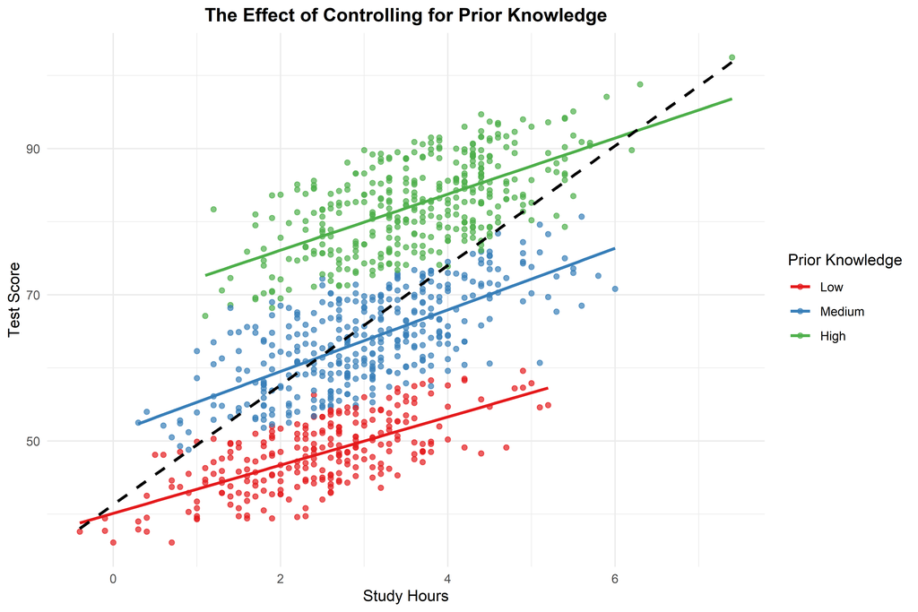

Study Hours vs. Test Score stratified by Prior Knowledge

```r
p_stratified <- ggplot(data, aes(x = study_hours, y = test_score, color = prior_knowledge_group)) +
  geom_point(alpha = 0.7) +
  # Lines for each prior knowledge group (controlled)
  geom_smooth(method = "lm", se = FALSE) +
  # Overall line (uncontrolled)
  geom_smooth(data = data, aes(x = study_hours, y = test_score, group = 1),
              method = "lm", color = "black", linetype = "dashed", se = FALSE) +
  scale_color_brewer(palette = "Set1") +
  labs(x = "Study Hours", y = "Test Score", color = "Prior Knowledge",
       title = "The Effect of Controlling for Prior Knowledge") +
  theme_minimal() +
  theme(plot.title = element_text(hjust = 0.5, face = "bold"))

p_stratified
```

This stratification approach is mathematically equivalent to estimating separate regression equations for each level of the control variable:

$$\text{TestScore}_{\text{low}} = \beta_{0,\text{low}} + \beta_{1,\text{low}} \times \text{StudyHours} + \varepsilon_{\text{low}}$$
$$\text{TestScore}_{\text{medium}} = \beta_{0,\text{medium}} + \beta_{1,\text{medium}} \times \text{StudyHours} + \varepsilon_{\text{medium}}$$
$$\text{TestScore}_{\text{high}} = \beta_{0,\text{high}} + \beta_{1,\text{high}} \times \text{StudyHours} + \varepsilon_{\text{high}}$$

When slopes ($\beta_1$) are similar across groups but intercepts differ, this suggests an additive effect of the control variable.

### 4. Understanding the Visualization

The visualization demonstrates several critical aspects of controlling for variables:

The mathematical reason for confounding bias can be illustrated using our model estimates:

```r
# Fit models with and without control
model_raw <- lm(test_score ~ study_hours, data = data)
model_controlled <- lm(test_score ~ study_hours + prior_knowledge, data = data)

# Print model summaries
broom::tidy(model_raw)
```

```
# A tibble: 2 × 5
  term        estimate std.error statistic   p.value
  <chr>          <dbl>     <dbl>     <dbl>     <dbl>
1 (Intercept)    41.3      1.08       38.3 4.76e-198
2 study_hours     8.18     0.327      25.1 7.76e-108
```

```r
broom::tidy(model_controlled)
```

```
# A tibble: 3 × 5
  term            estimate std.error statistic p.value
  <chr>              <dbl>     <dbl>     <dbl>   <dbl>
1 (Intercept)        30.0     0.0983     305.        0
2 study_hours         3.06    0.0316      96.8       0
3 prior_knowledge     4.97    0.0137     364.        0
```

```r
# Create coefficient comparison table
coef_raw <- coef(model_raw)
coef_controlled <- coef(model_controlled)

coef_table <- data.frame(
  Model = c("Without Control", "With Control"),
  "Study Hours Coefficient" = c(coef_raw[2], coef_controlled[2]),
  "Standard Error" = c(summary(model_raw)$coefficients[2,2],
                      summary(model_controlled)$coefficients[2,2])
)

coef_table %>%
  kable(caption = "Comparison of Study Hours coefficient", digits = 3) %>%
  kable_styling(bootstrap_options = c("striped", "hover"))
```

Comparison of Study Hours coefficient

| Model | Study.Hours.Coefficient | Standard.Error |
| --- | --- | --- |
| Without Control | 8.182 | 0.327 |
| With Control | 3.057 | 0.032 |

### 5. Understanding the Results

The table quantifies what we observed visually:

1. **Without controlling** for prior knowledge, each additional hour of studying is associated with an increase of approximately 8.18 points on the test.
2. **After controlling** for prior knowledge, each additional hour of studying is associated with an increase of approximately 3.06 points on the test.

This difference (8.18 - 3.06) demonstrates how failing to control for confounding variables leads to overestimating effects. The bias in our uncontrolled estimate can be calculated as:

$$\text{Bias} = \beta_1^* - \beta_1 = \beta_2 \times \delta_{X,Z}$$

Where:

The formula $\text{Bias} = \beta_2 \times \delta_{X,Z}$ mathematically explains omitted variable bias because:

1. $\beta_2$ represents how much the control variable Z affects Y
2. $\delta_{X,Z}$ represents how much Z is correlated with X

Their product gives the exact amount of bias when Z is omitted from the model.

This works because when Z is correlated with X, omitting Z causes X to “pick up” the effect of Z on Y. The stronger Z’s effect on Y ($\beta_2$) and the stronger the correlation between X and Z ($\delta_{X,Z}$), the larger the bias.

### 6. Residualization Method (The Frisch-Waugh-Lovell Theorem)

Another way to visualize controlling for a variable is through residualization:

```r
# Creating a 2x2 plot layout to explain residualization
# Step 1: Regress Study Hours on Prior Knowledge
hours_resid_model <- lm(study_hours ~ prior_knowledge, data = data)
data$hours_resid <- residuals(hours_resid_model)
data$hours_pred <- predict(hours_resid_model)

# Step 2: Regress Test Score on Prior Knowledge
score_resid_model <- lm(test_score ~ prior_knowledge, data = data)
data$score_resid <- residuals(score_resid_model)
data$score_pred <- predict(score_resid_model)

# Create plots
p_hours <- ggplot(data, aes(x = prior_knowledge, y = study_hours)) +
  geom_point(alpha = 0.6, color = "forestgreen") +
  geom_smooth(method = "lm", color = "darkblue") +
  geom_segment(aes(xend = prior_knowledge, yend = hours_pred),
               alpha = 0.2, color = "red") +
  # Add an example point for annotation
  geom_point(data = data[25,], color = "red", size = 3) +
  annotate("text", x = data[25,"prior_knowledge"]+0.8, y = data[25,"study_hours"]+0.5,
           label = "Student A", color = "red", fontface = "bold") +
  labs(x = "Prior Knowledge (Confounder)", y = "Study Hours (IV)",
       title = "Step 1: Regress Study Hours on Prior Knowledge") +
  theme_minimal() +
  theme(plot.title = element_text(hjust = 0.5, face = "bold"))

p_scores <- ggplot(data, aes(x = prior_knowledge, y = test_score)) +
  geom_point(alpha = 0.6, color = "orange") +
  geom_smooth(method = "lm", color = "darkblue") +
  geom_segment(aes(xend = prior_knowledge, yend = score_pred),
               alpha = 0.2, color = "red") +
  # Add the same example point
  geom_point(data = data[25,], color = "red", size = 3) +
  annotate("text", x = data[25,"prior_knowledge"]+0.8, y = data[25,"test_score"]+2,
           label = "Student A", color = "red", fontface = "bold") +
  labs(x = "Prior Knowledge (Confounder)", y = "Test Score (DV)",
       title = "Step 2: Regress Test Score on Prior Knowledge") +
  theme_minimal() +
  theme(plot.title = element_text(hjust = 0.5, face = "bold"))

# Step 3: Plot the residuals against each other
p_resid <- ggplot(data, aes(x = hours_resid, y = score_resid)) +
  geom_point(alpha = 0.6, color = "purple") +
  geom_smooth(method = "lm", color = "darkred") +
  geom_vline(xintercept = 0, col = "darkgray", lty = "dashed") +
  geom_hline(yintercept = 0, col = "darkgray", lty = "dashed") +
  # Add the same example point
  geom_point(data = data[25,], color = "red", size = 3) +
  xlim(-3, 3) +
  annotate("text", x = data[25,"hours_resid"]+0.7, y = data[25,"score_resid"]+1,
           label = "Student A\n(residualized values)", color = "red", fontface = "bold") +
  # Add quadrant labels
  annotate("text", x = 2, y = 12, label = "Studies more than predicted,\nscores higher than predicted",
           hjust = 0.5, vjust = 0.5, color = "darkblue", size = 4) +
  annotate("text", x = -2, y = 12, label = "Studies less than predicted,\nscores higher than predicted",
           hjust = 0.5, vjust = 0.5, color = "darkblue", size = 4) +
  annotate("text", x = 2, y = -12, label = "Studies more than predicted,\nscores lower than predicted",
           hjust = 0.5, vjust = 0.5, color = "darkblue", size = 4) +
  annotate("text", x = -2, y = -12, label = "Studies less than predicted,\nscores lower than predicted",
           hjust = 0.5, vjust = 0.5, color = "darkblue", size = 4) +
  labs(x = "Study Hours (residualized: red vertical lines from step 1)",
       y = "Test Score (residualized: red vertical lines from step 2)",
       title = "Step 3: Plot Residuals Against Each Other",
       subtitle = "This shows the relationship after controlling for Prior Knowledge") +
  theme_minimal() +
  theme(plot.title = element_text(hjust = 0.5, face = "bold"),
        plot.subtitle = element_text(hjust = 0.5))

# Arrange all plots in a 2x1 grid
(p_hours | p_scores) / (p_resid)
```

[figure not shown]

The residualization method is based on the **Frisch–Waugh–Lovell theorem**, which shows that in a multiple regression:

$$Y = \beta_0 + \beta_1X + \beta_2Z + \varepsilon$$

The coefficient $\beta_1$ can be estimated in two mathematically equivalent ways:

1. Direct multiple regression (as we did earlier)
2. Two-step process:
   - Step 1: Regress $X$ on $Z$ and compute residuals $e_X$: $X = \alpha_0 + \alpha_1Z + e_X$
   - Step 2: Regress $Y$ on $Z$ and compute residuals $e_Y$: $Y = \gamma_0 + \gamma_1Z + e_Y$
   - Step 3: Regress $e_Y$ on $e_X$: $e_Y = \delta_0 + \delta_1e_X + \nu$

The coefficient $\delta_1$ from Step 3 will be identical to $\beta_1$ from the direct multiple regression (model with control).

**Residualization Process Summary**

- Mathematically removes the influence of the control variable
- Step 1: Predict study hours from prior knowledge; calculate residuals
- Step 2: Predict test scores from prior knowledge; calculate residuals
- Step 3: Analyze relationship between these unpredicted portions (residuals)
- The slope equals the controlled coefficient in multiple regression
- Shows the X-Y relationship that cannot be explained by the control variable

### 7. Explaining the Residualization Process

The three-panel visualization demonstrates the mathematical process of controlling through residualization:

**Top Left Panel - Step 1**: Regress Study Hours on Prior Knowledge.

$$\text{StudyHours} = \alpha_0 + \alpha_1 \times \text{PriorKnowledge} + e_{\text{StudyHours}}$$

- Blue line: Predicted relationship between prior knowledge and study hours
- Green dots: Students’ actual data points
- Red vertical lines: Residuals ($e_{\text{StudyHours}}$) - how much a student’s study hours differ from prediction
- These residuals represent study hours AFTER removing the effect of prior knowledge

**Top Right Panel - Step 2**: Regress Test Score on Prior Knowledge.

$$\text{TestScore} = \gamma_0 + \gamma_1 \times \text{PriorKnowledge} + e_{\text{TestScore}}$$

- Blue line: Predicted relationship between prior knowledge and test scores
- Orange dots: Students’ actual test scores
- Red vertical lines: Residuals ($e_{\text{TestScore}}$) - how much a student’s score differs from prediction
- These residuals represent test scores AFTER removing the effect of prior knowledge

**Bottom Panel - Step 3**: Plot the residuals against each other.

$$e_{\text{TestScore}} = \delta_0 + \delta_1 \times e_{\text{StudyHours}} + \nu$$

- X-axis: How much a student study hours more/less than predicted based on prior knowledge
- Y-axis: How much a student scores better/worse than predicted based on prior knowledge
- Point (0,0): Represents students who study exactly as much as predicted and score exactly as predicted based on their prior knowledge - the “baseline” case where prior knowledge fully explains both behaviors.
- Red line: The “pure” effect of study hours on test scores after removing prior knowledge’s influence. Since we’ve removed the effect of prior knowledge from both variables, we’re now seeing the “pure” relationship between them - the effect of studying that can’t be explained away by saying “they just had more prior knowledge.
- Residuals in this plot: The vertical distance from each point to the red line shows how much each student’s test score deviates from what we’d predict based on both their prior knowledge and study hours combined.
- This relationship is mathematically equivalent to the coefficient of study hours in our multiple regression model

```r
# Verify that the residualization method gives the same coefficient
residual_model <- lm(score_resid ~ hours_resid, data = data)

# Compare coefficients
equivalence_check <- data.frame(
  Method = c("Multiple Regression", "Residualization"),
  "Study Hours Coefficient" = c(coef_controlled[2], coef(residual_model)[2])
)

equivalence_check %>%
  kable(caption = "Coefficient Equivalence Between Methods", digits = 3) %>%
  kable_styling(bootstrap_options = c("striped", "hover"))
```

Coefficient Equivalence Between Methods

|  | Method | Study.Hours.Coefficient |
| --- | --- | --- |
| study_hours | Multiple Regression | 3.057 |
| hours_resid | Residualization | 3.057 |

As demonstrated, the coefficient from the residualization method is mathematically equivalent to the multiple regression coefficient, confirming our approach’s validity.

### 8. Conclusion

Controlling for variables is essential in statistical analysis because it:

1. Isolates the unique effect of our independent variable on the dependent variable
2. Removes the influence of confounding factors that might bias our results
3. Provides a more accurate understanding of relationships between variables
4. Allows for more valid inferences, especially in observational studies

Through visualization and mathematical explanation, we’ve seen how controlling for prior knowledge changes our understanding of how study hours affect test scores. While studying does improve scores, its effect is not as strong as an uncontrolled analysis would suggest.

The true coefficient (3.0) matches our data generation process, where we explicitly set the direct effect of study hours to be 3.0. This confirms that proper controlling techniques can recover the true underlying relationships in our data.